# main

Harrison Burke

12/3/2019

## The research question(s)

What is the relationship between rowing success and economic success?

## Background/significance of the research

My goal in this project was to take a deeper dive into factors that influence rowing success at the Olympics. The stereotype of the sport is that it’s elitist and only for the wealthy, so I made a point to look at the relationship between wealth metrics and rowing results. Furthermore, there is a surprising lack of interesting rowing data on the web, so even exploring within the dataset will uncover some interesting stories.

## The methods used to obtain and analyze the data

I completed the project entirely in R. I downloaded datasets from Kaggle and the World Banks, and mainly used the tidyverse library to clean, transform, and merge the data. Once aggregated, I used many different libraries to help me manipulate the data to get the information I wanted. A list of libraries that I used will be attached here:

shiny plotly shinyWidgets fs shinythemes moderndive gt tidyverse countrycode

I performed standard linear regression with GDP Per Capita as the explanatory variable, and the medal count at the olympics for the dependent variable. I visualized this relationship with a scatter plot and a regression line, and I printed the output of the model to a table.

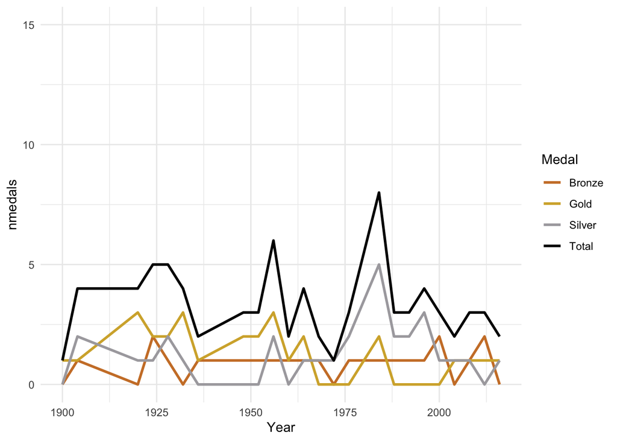

## The results of the analysis (tables, charts, graphs, significance, confidence intervals, descriptive text)

Here, I am only looking at the data for the United States. As is clear in the graph, there is not a strong relationship between GDP per capita and the number of medals won at the olympics.

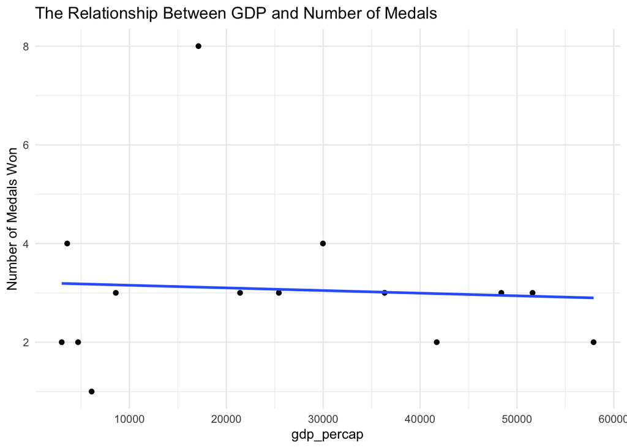

Country GDP Per Capita and Number of Medals Won

[output not shown]

| Country | # of Medals per Million People |
| --- | --- |
| Denmark | 0.3800060573 |
| Australia | 0.3276718912 |
| Switzerland | 0.2828114284 |
| Norway | 0.2282408836 |
| Canada | 0.2022115200 |
| Belarus | 0.1968503937 |
| Netherlands | 0.1931683066 |
| Romania | 0.0884212231 |
| France | 0.0669421358 |
| Germany | 0.0488312062 |
| United Kingdom | 0.0343837867 |
| Ukraine | 0.0195858805 |
| Italy | 0.0175869690 |
| United States | 0.0148481406 |
| Russia | 0.0067494581 |
| China | 0.0008213215 |
| Algeria | 0.0000000000 |
| Argentina | 0.0000000000 |
| Austria | 0.0000000000 |
| Belgium | 0.0000000000 |
| Brazil | 0.0000000000 |
| Bulgaria | 0.0000000000 |
| Croatia | 0.0000000000 |
| Cuba | 0.0000000000 |
| Czechia | 0.0000000000 |
| Egypt | 0.0000000000 |
| Estonia | 0.0000000000 |
| Finland | 0.0000000000 |
| Greece | 0.0000000000 |
| Hong Kong SAR China | 0.0000000000 |
| Hungary | 0.0000000000 |
| Ireland | 0.0000000000 |
| Japan | 0.0000000000 |
| Latvia | 0.0000000000 |
| Lithuania | 0.0000000000 |
| Mexico | 0.0000000000 |
| New Zealand | 0.0000000000 |
| Poland | 0.0000000000 |
| Portugal | 0.0000000000 |
| Slovakia | 0.0000000000 |
| Slovenia | 0.0000000000 |
| South Africa | 0.0000000000 |
| South Korea | 0.0000000000 |
| Spain | 0.0000000000 |
| Sweden | 0.0000000000 |